# OECD

### 2.4. Graphs

#### 2.4.1 DP_LIVE_28032020124154065.csv

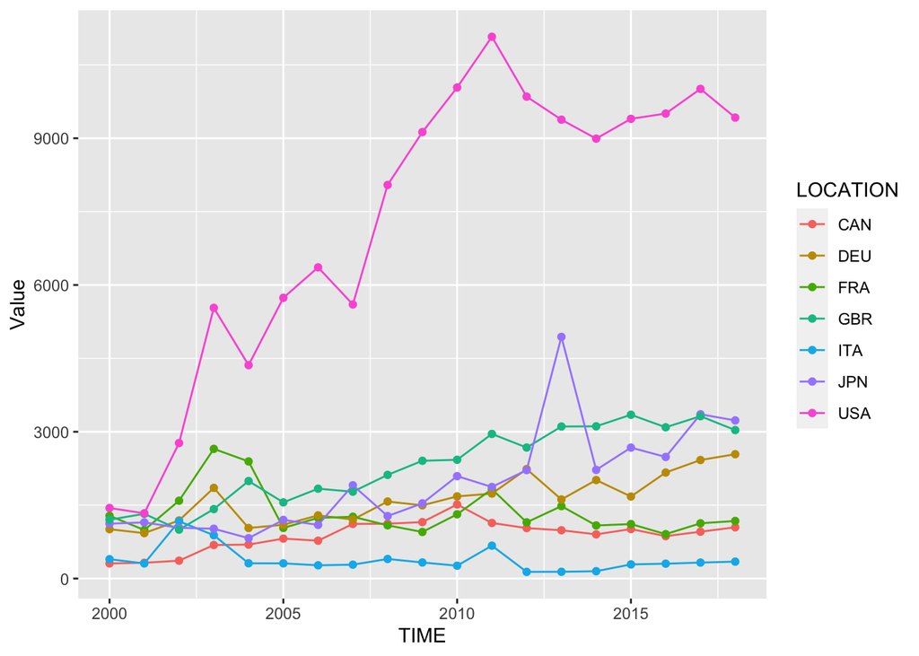

```r
dp_live %>% ggplot(aes(x = TIME, y = Value)) +
  geom_line(aes(color = LOCATION)) +
  geom_point(aes(color = LOCATION))
```

#### 2.4.2 OECD.Stat Data

**DATATYPE: A, Current Prices**

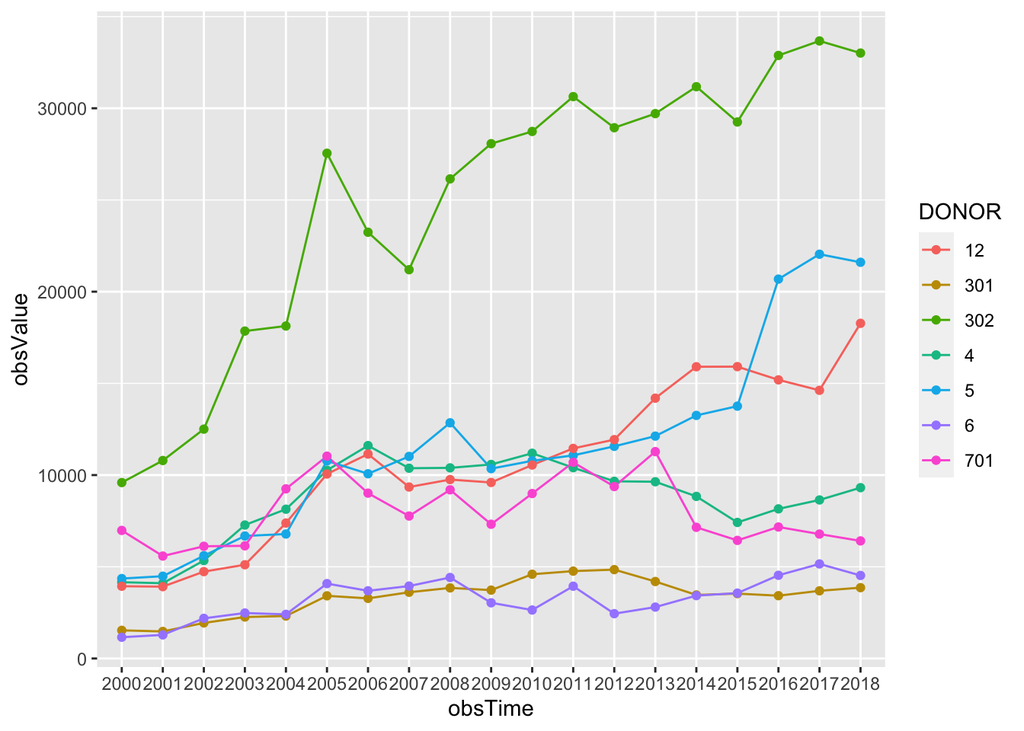

```r
dac2a_df %>% group_by(DONOR) %>% filter(DATATYPE == "A") %>% select(DONOR, obsTime, obsValue) %>%
  ggplot(aes(x = obsTime, y = obsValue, group = DONOR)) +
  geom_line(aes(color = DONOR)) +
  geom_point(aes(color = DONOR))
```

**DATATYPE: D, Constant Prices**

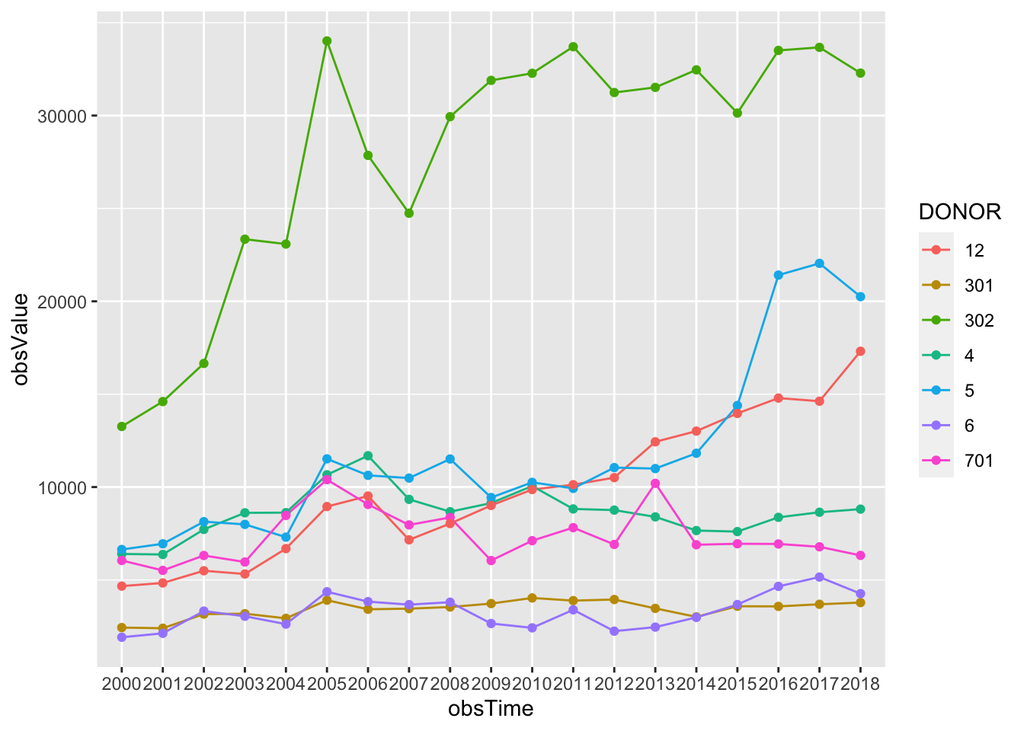

```r
dac2a_df %>% group_by(DONOR) %>% filter(DATATYPE == "D")  %>%
  ggplot(aes(x = obsTime, y = obsValue, group = DONOR)) +
  geom_line(aes(color = DONOR)) +
  geom_point(aes(color = DONOR))
```

#### 2.4.3 `OECD` Package

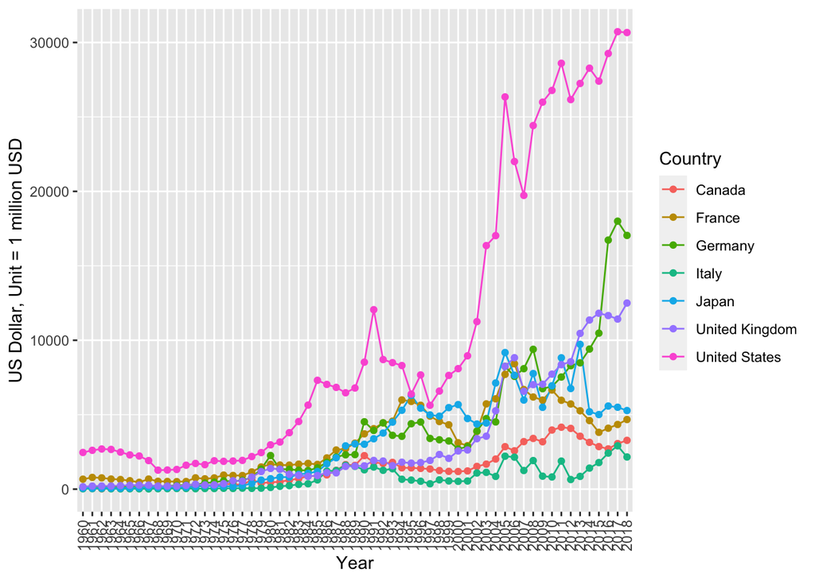

```r
dff %>% filter(RECIPIENT == "10100", AIDTYPE == "201", Country %in% country, DATATYPE == "A")  %>%
  ggplot(aes(x = obsTime, y = obsValue, group = Country)) +
  geom_line(aes(color = Country)) +
  geom_point(aes(color = Country)) +
  theme(axis.text.x = element_text(angle = 90, vjust = 0.5, hjust = 1)) +
  labs(x = "Year", y = "US Dollar, Unit = 1 million USD")
```

## 3. Memorandom メモ

- [vignettes](https://cran.r-project.org/web/packages/OECD/vignettes/oecd_vignette_main.html) には、SDMX (XML) を、`get_dataset()` に代入して、データを取得する方法が書いてあったが、適切にできず、`rsdmx` Package を使用。
- OECD.Stat の SDMX (XML) からデータを取得すると、Country が Code になってしまい、OECD Package などから入手したデータを用いれば、Country 名を入れられるが、直接そのデータを残す方法が見つからず。
- `OECD` Package でデータを入手するとき、filter を試すが、あまりうまくいかない。